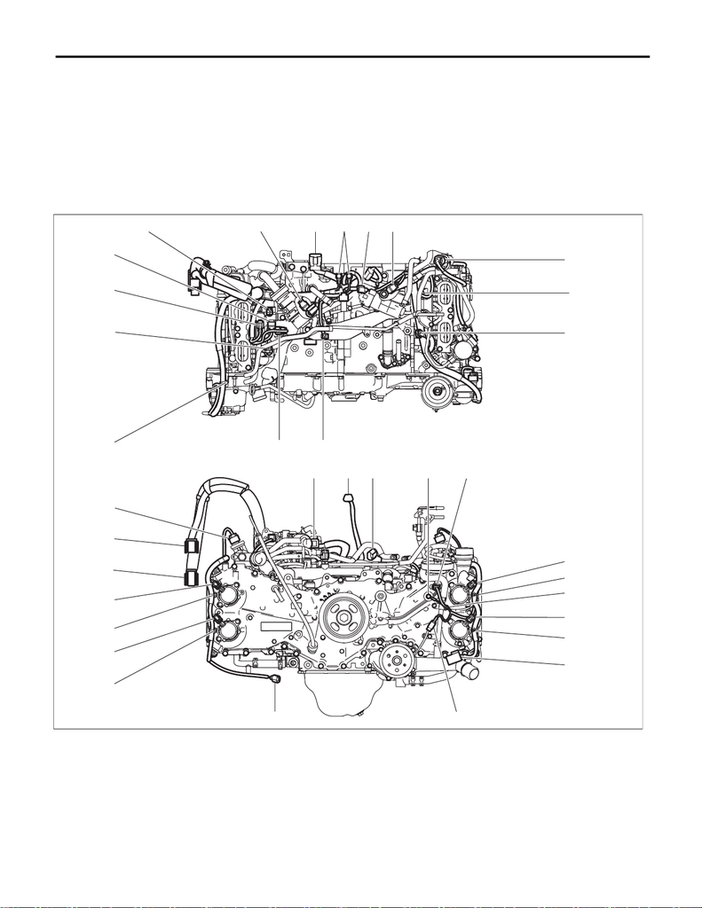

FU(w/o STI)-85

Engine Wiring Harness

FUEL INJECTION (FUEL SYSTEMS)

10.Engine Wiring Harness

A: REMOVAL

1) Disconnect the ground terminal from battery sensor. <Ref. to NT-5, BATTERY, NOTE, Note.>

2) Remove the intake manifold. <Ref. to FU(w/o STI)-18, REMOVAL, Intake Manifold.>

3) Remove the fuel insulator. <Ref. to FU(w/o STI)-46, REMOVAL, Fuel Insulator.>

4) Remove the engine control module (ECM). <Ref. to FU(w/o STI)-132, REMOVAL, Engine Control Module

(ECM).>

5) Disconnect the connector from the engine.

• Structural diagram 1

FU-08360

(1) (2) (3) (4)

(5)

(6)

(7)

(8)

(9)

(27)

(10)

(16) (17) (18) (19) (20)

(21)

(22)

(23)

(24)

(25)

(26)

(11)

(28)

(29)

(30)

(31)

(32)

(33)

(34)

(12)

(13)

(14)

(15)

(35)

[figure not shown]

FU(w/o STI)-86

Engine Wiring Harness

FUEL INJECTION (FUEL SYSTEMS)

(1) Knock sensor RH

(2) Engine harness connector (16P)

(3) Engine ground (2 locations)

(4) Crankshaft position sensor

(5) Knock sensor LH

(6) Tumble generator valve actuator LH

(7) Fuel injector (#4)

(8) Fuel injector (#2)

(9) Engine coolant temperature sensor

(10) Fuel pressure sensor

(11) Remove clip from screw hole.

(12) Fuel injector (#1)

(13) Purge control solenoid valve (#2) (black connector)

(14) Purge control solenoid valve (#1) (blue connector)

(15) Fuel injector (#3)

(16) EGR valve

(17) Manifold absolute pressure and intake air temperature sensor

(18) Throttle position sensor

(19) Oil pressure switch

(20) Engine oil temperature sensor

(21) Intake oil control solenoid LH

(22) Remove clip from screw hole.

(23) Remove clip from the round hole of stay.

(24) Exhaust oil control solenoid LH

(25) Remove clip from screw hole.

(26) Front oxygen (A/F) sensor (remove from the front oxygen (A/F) sensor bracket)

(27) Wastegate solenoid

(28) Remove clip from screw hole.

(29) Exhaust oil control solenoid RH

(30) Remove clip from screw hole.

(31) Intake oil control solenoid RH

(32) Engine harness connector (48P)

(33) Engine harness connector (32P)

(34) Tumble generator valve actuator RH

(35) Oil level sensor connector

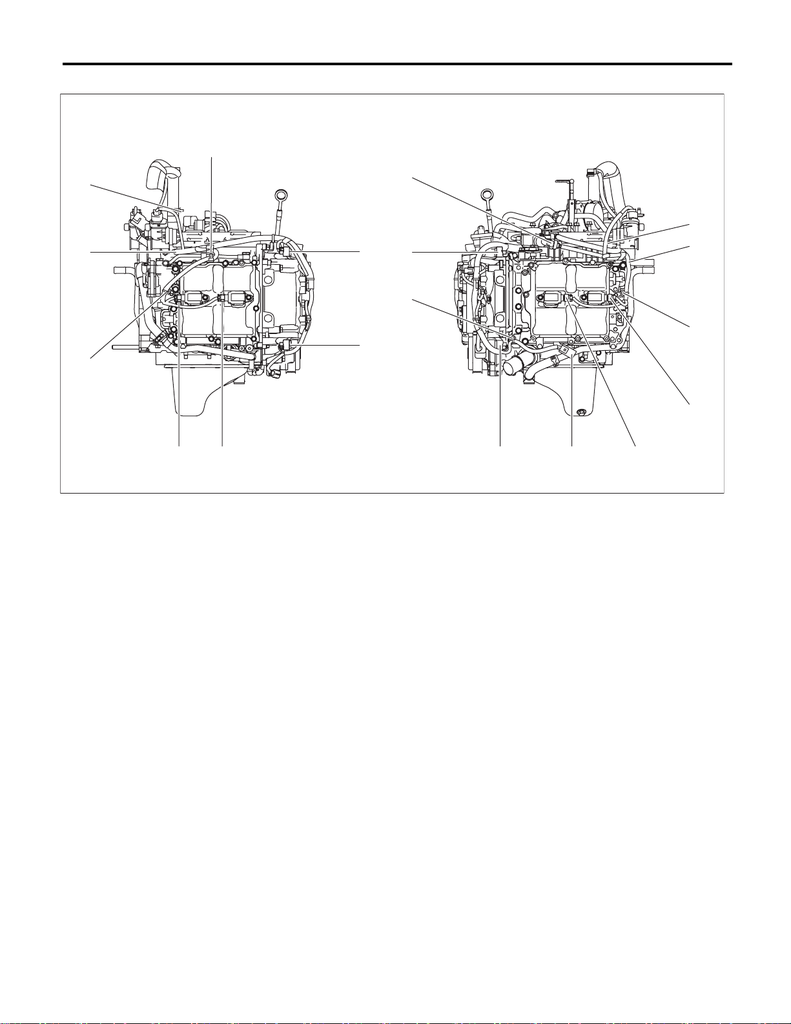

FU(w/o STI)-87

Engine Wiring Harness

FUEL INJECTION (FUEL SYSTEMS)

• Structural diagram 2

(1) Intake camshaft position sensor RH

(2) Exhaust camshaft position sensor RH

(3) Ignition coil No. 1

(4) Ignition coil No. 3

(5) Remove clip from screw hole.

(6) Pull out from the lower side of the tumble generator valve RH.

(7) Remove clip from the round hole.

(8) Remove clip from the oil pipe.

(9) Intake camshaft position sensor LH

(10) High-pressure fuel pump

(11) Pull out from the outside of the fuel tube.

(12) Pull out from the lower side of the tumble generator valve LH.

(13) Remove clip from screw hole.

(14) Ignition coil No. 4

(15) Ignition coil No. 2

(16) Oxygen sensor

(17) Exhaust camshaft position sensor LH

(18) Remove clip from screw hole.

FU-08487

(7)

(6)

(9)

(5)

(4)

(3)

(1)

(2)

(18)

(17)

(16) (15)

(14)

(13)

(12)

(11)

(8)

(10)

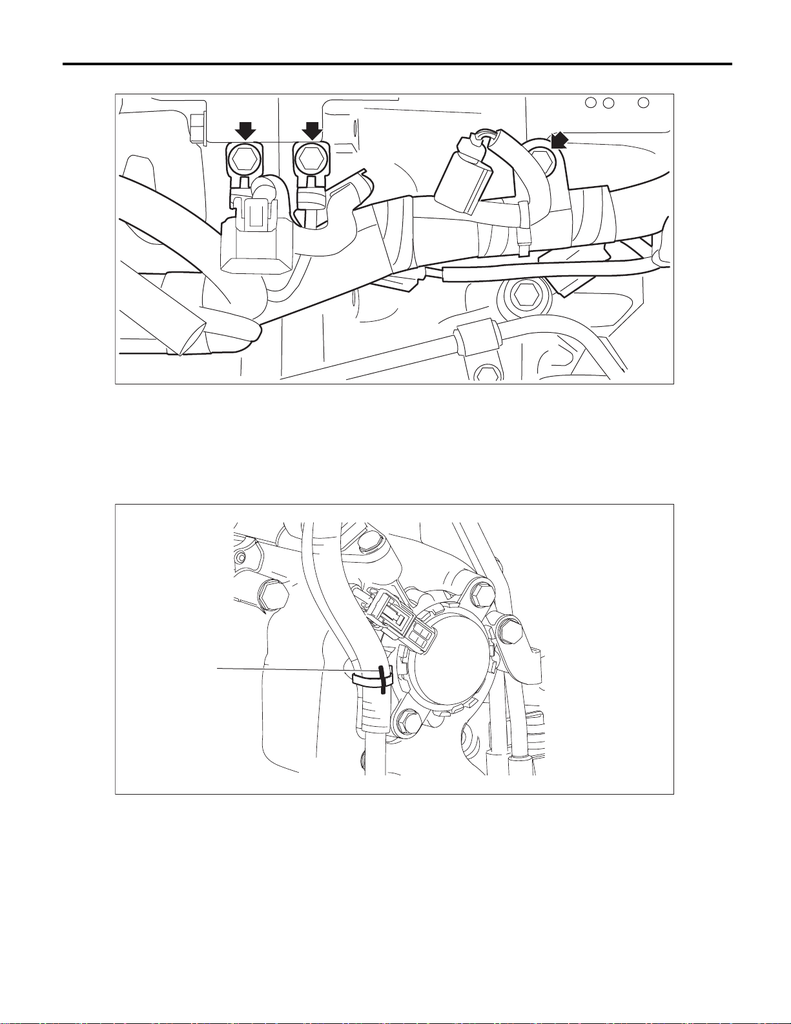

FU(w/o STI)-88

Engine Wiring Harness

FUEL INJECTION (FUEL SYSTEMS)

6) Remove the engine wiring harness.

B: INSTALLATION

1) Set the engine wiring harness to the engine, and connect the connector.

NOTE:

• If the clip is damaged, replace it with a new part.

• Before replacing the clip, put an alignment mark (a) on both engine wiring harness and clip to remove the

clip, and then align to the alignment mark (a) to attach a new clip to the engine wiring harness.

FU-08490

FU-08368

(a)

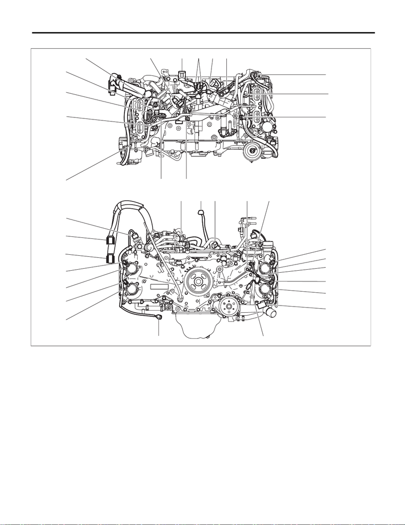

FU(w/o STI)-89

Engine Wiring Harness

FUEL INJECTION (FUEL SYSTEMS)

• Structural diagram 1

FU-08360

(1) (2) (3) (4)

(5)

(6)

(7)

(8)

(9)

(27)

(10)

(16) (17) (18) (19) (20)

(21)

(22)

(23)

(24)

(25)

(26)

(11)

(28)

(29)

(30)

(31)

(32)

(33)

(34)

(12)

(13)

(14)

(15)

(35)

[figure not shown]

FU(w/o STI)-90

Engine Wiring Harness

FUEL INJECTION (FUEL SYSTEMS)

(1) Knock sensor RH (routed under the insulator)

(2) Engine harness connector (16P) (secured to engine hanger)

(3) Engine ground (2 places) (During installation, let the terminal tip come in contact with the block step.)

(4) Crankshaft position sensor

(5) Knock sensor LH (routed under the insulator)

(6) Tumble generator valve actuator LH

(7) Fuel injector (#4) (routed under the insulator)

(8) Fuel injector (#2) (routed under the insulator)

(9) Engine coolant temperature sensor

(10) Fuel pressure sensor

(11) Secure the clip to the screw hole.

(12) Fuel injector (#1) (routed under the insulator)

(13) Purge control solenoid valve (#2) (black connector)

(14) Purge control solenoid valve (#1) (blue connector)

(15) Fuel injector (#3) (routed under the insulator)

(16) EGR valve

(17) Manifold absolute pressure and intake air temperature sensor

(18) Throttle position sensor

(19) Oil pressure switch

(20) Engine oil temperature sensor

(21) Intake oil control solenoid LH

(22) Secure the clip to the screw hole.

(23) Secure the clip to the round hole of stay.

(24) Exhaust oil control solenoid LH

(25) Secure the clip to the screw hole.

(26) Front oxygen (A/F) sensor (secured to the front oxygen (A/F) sensor bracket)

(27) Wastegate solenoid

(28) Secure the clip to the screw hole.

(29) Exhaust oil control solenoid RH

(30) Secure the clip to the screw hole.

(31) Intake oil control solenoid RH

(32) Engine harness connector (48P)

(33) Engine harness connector (32P)

(34) Tumble generator valve actuator RH

(35) Oil level sensor connector

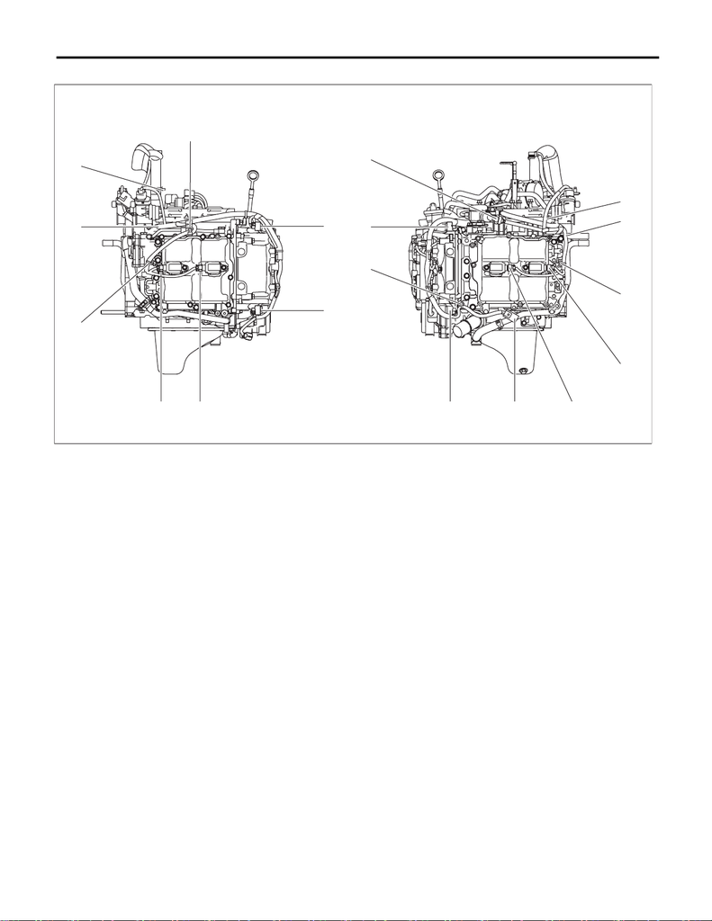

FU(w/o STI)-91

Engine Wiring Harness

FUEL INJECTION (FUEL SYSTEMS)

• Structural diagram 2

(1) Intake camshaft position sensor RH

(2) Exhaust camshaft position sensor RH

(3) Ignition coil No. 1

(4) Ignition coil No. 3

(5) Secure the clip to the screw hole.

(6) Route under the tumble generator valve.

(7) Secure the clip to the round hole.

(8) Secure the clip to the oil pipe.

(9) Intake camshaft position sensor LH

(10) High-pressure fuel pump

(11) Route outside of the fuel tube.

(12) Route under the tumble generator valve.

(13) Secure the clip to the screw hole.

(14) Ignition coil No. 4

(15) Ignition coil No. 2

(16) Oxygen sensor (secured to the heater pipe)

(17) Exhaust camshaft position sensor LH

(18) Secure the clip to the screw hole.

FU-08487

(7)

(6)

(9)

(5)

(4)

(3)

(1)

(2)

(18)

(17)

(16) (15)

(14)

(13)

(12)

(11)

(8)

(10)

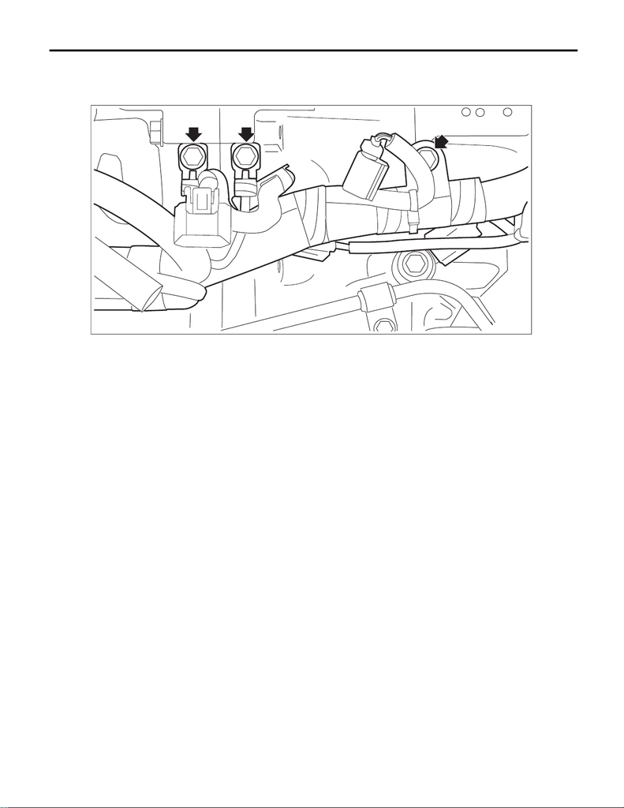

FU(w/o STI)-92

Engine Wiring Harness

FUEL INJECTION (FUEL SYSTEMS)

2) Install the engine wiring harness.

Tightening torque:

19 N·m (1.9 kgf-m, 14.0 ft-lb)

3) Install the engine control module (ECM). <Ref. to FU(w/o STI)-134, INSTALLATION, Engine Control Mod-

ule (ECM).>

4) Install the fuel insulator. <Ref. to FU(w/o STI)-49, INSTALLATION, Fuel Insulator.>

5) Install the intake manifold. <Ref. to FU(w/o STI)-29, INSTALLATION, Intake Manifold.>

6) Connect the ground terminal to battery sensor. <Ref. to NT-5, BATTERY, NOTE, Note.>

C: INSPECTION

1) Check that the engine wiring harness does not have deformation, cracks and any other damage.

2) Check the engine wiring harness for contamination or clogging.

FU-08490